# ASM_Assignment2

Robert Wilbrand

2021-05-01

```r
# load necessary packages
library(rethinking)
library(tidyverse)
library(brms)
data(homeworkch3)

# set global options
theme_set(theme_minimal())
knitr::opts_knit$set(root.dir = "C:/MSc GCG/2021_SoSe/ASM")
knitr::opts_chunk$set(message = FALSE, warning = FALSE)
options(scipen = 8) # disables scientific notation up to 8 digits

# Wrapper function to set a specified seed prior to function execution
# useful because it leaves the seed outside the function unaffected
seedFunc <- function(func, seed, ...){
  set.seed(seed)
  func(...)
}
```

## 3H1.

Using grid approximation, compute the posterior distribution for the probability of a birth being a boy. Assume a uniform prior probability. Which parameter value maximizes the posterior probability?

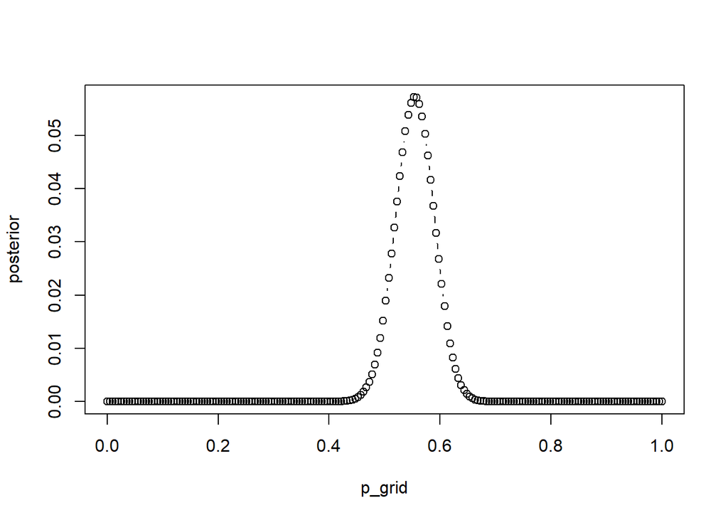

```r
boys_sum <- sum(birth1, birth2)
p_grid <- seq(0, 1, length.out=200)
prior <- rep(1,200)
likelihood <- dbinom(boys_sum, 200, p_grid)
posterior <- likelihood * prior
posterior <- posterior / sum(posterior)
plot(p_grid, posterior, type="b")
```

```r
p_grid[which.max(posterior)]
```

```
## [1] 0.5527638
```

For this approximation, the probability of a birth being a boy is maximal at 55.3 %.

## 3H2.

Using the sample function, draw 10,000 random parameter values from the posterior distribution you calculated above. Use these samples to estimate the 50%, 89%, and 97% highest posterior density intervals.

```r
sampleBirths <- seedFunc(sample, 1234, p_grid, 1e4,
                         replace = T, prob = posterior)

HPDI(sampleBirths, prob = 0.5) %>% round(3)
```

```
##  |0.5  0.5|
## 0.523 0.568
```

```r
HPDI(sampleBirths, prob = 0.89) %>% round(3)
```

```
## |0.89 0.89|
## 0.497 0.608
```

```r
HPDI(sampleBirths, prob = 0.97) %>% round(3)
```

```
## |0.97 0.97|
## 0.482 0.628
```

## 3H3.

Use rbinom to simulate 10,000 replicates of 200 births. You should end up with 10,000 numbers, each one a count of boys out of 200 births. Compare the distribution of predicted numbers of boys to the actual count in the data (111 boys out of 200 births). There are many good ways to visualize the simulations, but the dens command (part of the rethinking package) is probably the easiest way in this case. Does it look like the model fits the data well? That is, does the distribution of predictions include the actual observation as a central, likely outcome?

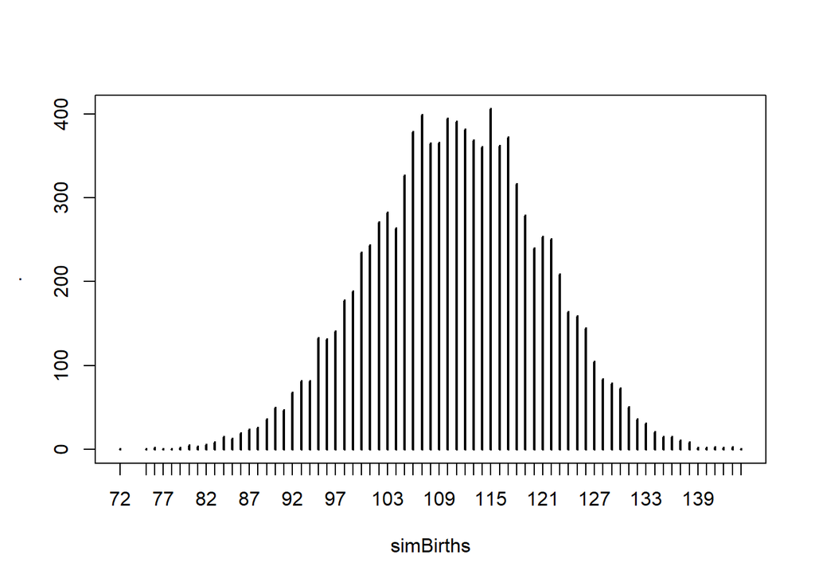

```r
simBirths <- seedFunc(rbinom, 139, 1e4, 200, sampleBirths)
table(simBirths) %>% plot
```

```r
table(simBirths) %>% as_tibble %>% arrange(desc(n)) %>% head
```

```
## # A tibble: 6 x 2
##   simBirths     n
##   <chr>     <int>
## 1 115         406
## 2 107         399
## 3 110         395
## 4 111         391
## 5 112         382
## 6 106         379
```

The observed value of 111 is located centrally in the distribution, although it is only the 4th most frequent value in this particular simulation.

## BRMS————————————————————————-

## 3H1.

```r
library(brms)
m1 <- brm(data = list(boys_sum = boys_sum),
          family = binomial(link = "identity"),
          boys_sum | trials(200) ~ 0 + Intercept,
          prior(beta(1, 1), class = b, lb = 0, ub = 1),
          iter = 10000,
          seed = 5429)
summary(m1)
```

```
##  Family: binomial
##   Links: mu = identity
## Formula: boys_sum | trials(200) ~ 0 + Intercept
##    Data: list(boys_sum = boys_sum) (Number of observations: 1)
## Samples: 4 chains, each with iter = 10000; warmup = 5000; thin = 1;
##          total post-warmup samples = 20000
##
## Population-Level Effects:
##           Estimate Est.Error l-95% CI u-95% CI Rhat Bulk_ESS Tail_ESS
## Intercept     0.55      0.03     0.48     0.62 1.00     6651     9898
##
## Samples were drawn using sampling(NUTS). For each parameter, Bulk_ESS
## and Tail_ESS are effective sample size measures, and Rhat is the potential
## scale reduction factor on split chains (at convergence, Rhat = 1).
```

```r
print("")
```

```
## [1] ""
```

```r
(post_smry <- posterior_summary(m1))
```

```
##               Estimate  Est.Error       Q2.5      Q97.5
## b_Intercept  0.5538021 0.03481025  0.4844817  0.6219986
## lp__        -4.7674609 0.71625421 -6.8155527 -4.2689003
```

```r
print("")
```

```
## [1] ""
```

```r
fitted(m1)
```

```
##      Estimate Est.Error     Q2.5    Q97.5
## [1,] 110.7604   6.96205 96.89635 124.3997
```

```r
print("")
```

```
## [1] ""
```

```r
predict(m1)
```

```
##      Estimate Est.Error Q2.5 Q97.5
## [1,] 110.7224  9.835619   91   130
```

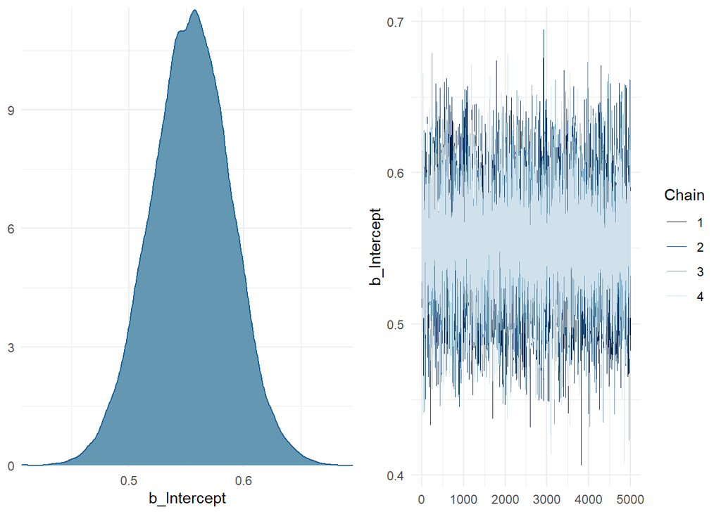

```r
plot(m1)
```

The posterior probability is maximized here at 55.4 %.

## 3H2.

```r
fBrms <-fitted(m1,
         summary = F,
         scale   = "linear") %>%
  as.vector()

HPDI(fBrms, prob=c(0.5, 0.89, 0.97)) %>% round(3)
```

```
## |0.97 |0.89  |0.5  0.5| 0.89| 0.97|
## 0.476 0.500 0.533 0.579 0.610 0.627
```

```r
# map(c(0.5, 0.89, 0.97), ~HPDI(fBrms, prob = .x))
```

## 3H3.

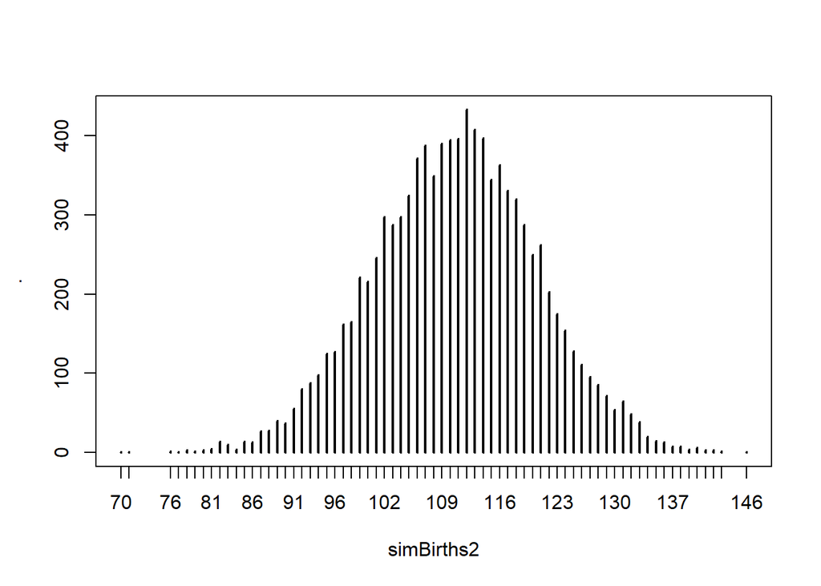

```r
simBirths2 <- seedFunc(rbinom, 159, 1e4, 200, fBrms)
table(simBirths2) %>% plot
```

```r
table(simBirths2) %>% as_tibble %>% arrange(desc(n)) %>% head
```

```
## # A tibble: 6 x 2
##   simBirths2     n
##   <chr>      <int>
## 1 112          433
## 2 113          408
## 3 114          397
## 4 111          396
## 5 110          395
## 6 109          390
```

Again, the observed value of 111 is the 4th most frequent value, but as the graph and table show, the 6 most frequent values overall are clustered around it.